# What factors determine interest rate?

### Investigation Overview

In this investigation, I wanted to look at the characteristics of loans that could be used to predict interest rate. The main focus was on borrowers' wealth and their credit scores and ratings

### Data Structure

This data set (`prosperLoanData.csv`) has 113937 rows and 81 columns (`BorrowerRate, Occupation, Borrower State.. etc`).

### Main features of interest in the dataset

I want to investigate what factors are best for predicting features that affect interest rate (`BorrowerRate`).

### Features that help to support my investigation into my features of interest

I expect that `ProsperRating (Alpha)`, `ProsperScore`, and `CreditGrade` have the strongest impact on interest rate (`BorrowerRate`) and I think that `BorrowerRate` is also associated with the person's wealth (such as whether the borrower has a house (`IsBorrowerHomeowner`), `IncomeRange`).

## Distribution of BorrowerRate

The interest rate in the dataset vary from the lowest of 0 to the highest of 0.4975. The histogram of `BorrowerRate` shows slightly a right skewed shape and has the highest peak at around 0.31~0.32.

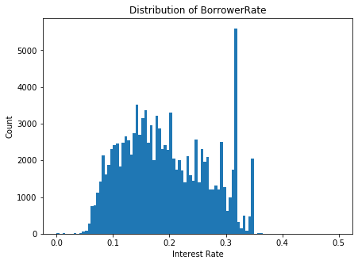

```python
bins =  np.arange(df['BorrowerRate'].min(), df['BorrowerRate'].max() + 0.005, 0.005);
plt.figure(figsize=[7, 5]);
plt.title('Distribution of BorrowerRate');
plt.hist(df['BorrowerRate'], bins=bins);
plt.xlabel('Interest Rate');
plt.ylabel('Count');
plt.show();
```

## Distribution of ProsperRating (Alpha)

ProsperRating (Alpha) is a measure for assessing a borrower's credit (0 - N/A, 1 - HR, 2 - E, 3 - D, 4 - C, 5 - B, 6 - A, 7 - AA). The plot of ProsperRating (Alpha) shows a symmetric distribution. The main group of the borrowers have C and only few people have AA grade.

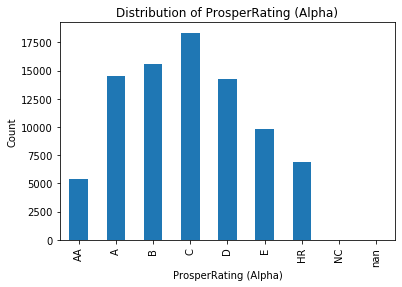

```python
df.groupby('ProsperRating (Alpha)')['ListingKey'].count().plot.bar();
plt.title('Distribution of ProsperRating (Alpha)');
plt.ylabel('Count')
plt.show();
# print('ProsperRating (Alpha) Percentage',df['ProsperRating (Alpha)'].value_counts(normalize=True) * 100)
```

## Distribution of CreditGrade

The Credit rating is a measure of assessing a borrower's credit. Unlike ProsperRate, CreditGrade shows more AA grades than A grades. Furthermore, HR group is more than E and A groups.

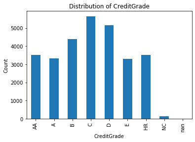

```python
df.groupby('CreditGrade')['ListingKey'].count().plot.bar()
plt.title('Distribution of CreditGrade');
plt.ylabel('Count')
plt.show()
# print('CreditGrade Percentage',df['CreditGrade'].value_counts(normalize=True) * 100)
```

## Distribution of Term

Term is the length of the loan expressed in months. Most of the loans have 36 months and less than 2 %of the borrowers have 12 month loans.

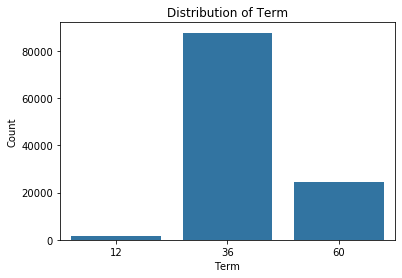

```python
# let's have look at Term
default_color = sns.color_palette()[0];
plt.figure(figsize=(6,4));
plt.title('Distribution of Term');
sns.barplot(x=df['Term'].value_counts().index, y=df['Term'].value_counts().values, color=default_color);
plt.ylabel('Count');
plt.xlabel('Term');
plt.show();
# print('Term Percentage',df['Term'].value_counts(normalize=True) * 100)
```

## Distribution of ProsperScore

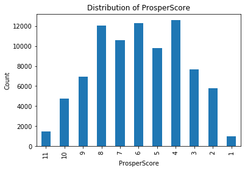

```python
df.groupby(['ProsperScore'])['ListingKey'].count().plot.bar();
plt.title('Distribution of ProsperScore');
plt.ylabel('Count');
plt.show();
# print('ProsperScore Percentage',df['ProsperScore'].value_counts(normalize=True) * 100)
```

## Distribution of EmploymentStatus

The employment status shows borrowers' employment status. The majority of the borrowers is employed (categorised as Employed or Full-time). Interestingly, there is even retired people.

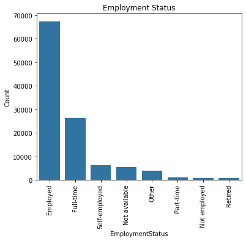

```python
default_color = sns.color_palette()[0];
plt.figure(figsize=(6,5));
sns.barplot(x=df['EmploymentStatus'].value_counts().index,y=df['EmploymentStatus'].value_counts().values, color=default_color);
plt.title('Distribution of EmploymentStatus');
plt.ylabel('Count');
plt.xlabel('EmploymentStatus');
plt.xticks(rotation=90);
plt.title('Employment Status');
plt.show();
# print('Employment Percentage',df['EmploymentStatus'].value_counts(normalize=True) * 100)
```

## Distribution of IsBorrowerHomeowner

In terms of whether the borrowers are homeowner or not, the ratio is half and half.

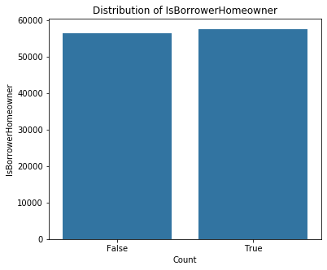

```python
default_color = sns.color_palette()[0];
plt.figure(figsize=(6,5));
sns.barplot(x=df['IsBorrowerHomeowner'].value_counts().index,y=df['IsBorrowerHomeowner'].value_counts().values, color=default_color);
plt.title('Distribution of IsBorrowerHomeowner');
plt.xlabel('Count');
plt.ylabel('IsBorrowerHomeowner');
plt.show()
# print('IsBorrowerHomeowner Percentage',df['IsBorrowerHomeowner'].value_counts(normalize=True) * 100)
```

## Distribution of IncomeRange and IncomeVerifiable

As for `IncomeRange`, the main groups are \$50,000-74,999 and \\$25,000-49,999 and there are more people of IncomeRange over \$75,000 than below \\$24,999 or no income. Regarding IncomeVerifiable, more than 90% incomes are verifiable although there are around 8% incomes which are not verifiable.

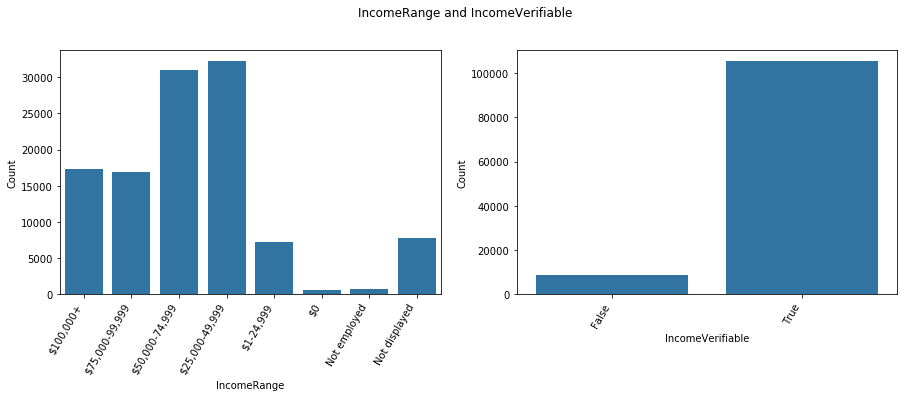

```python
# let's have look at IncomeRange and IncomeVerifiable
fig, ax = plt.subplots(ncols=2, figsize = [15,5]);

default_color = sns.color_palette()[0];
sns.barplot(x=df['IncomeRange'].value_counts().index,y=df['IncomeRange'].value_counts().values,
            color = default_color, ax = ax[0]);
sns.barplot(x=df['IncomeVerifiable'].value_counts().index,y=df['IncomeVerifiable'].value_counts().values,
            color = default_color, ax = ax[1]);
fig.autofmt_xdate(rotation=60);
plt.suptitle("IncomeRange and IncomeVerifiable", y = 1);
for i in [0,1]:
    ax[i].set_ylabel('Count');
ax[0].set_xlabel('IncomeRange');
ax[1].set_xlabel('IncomeVerifiable');
plt.show();
# print('IncomeRange Percentage',df['IncomeRange'].value_counts(normalize=True) * 100)
# print('IncomeVerifiable Percentage',df['IncomeVerifiable'].value_counts(normalize=True) * 100)
```

## Distribution of StatedMonthlyIncome

StatedMonthlyIncome is the monthly income the borrower stated at the time the listing was created. The natural plot of `StatedMonthlyIncome`is skewed strongly to the right. So I first changed the plot to logscale then set the limit between 1.5 to 5.5. Most of the borrowers get monthly less than \$10,000.

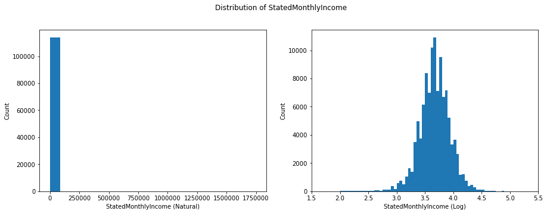

```python
fig, ax = plt.subplots(ncols=2, figsize = [15,5])

default_color = sns.color_palette()[0]
bins_log = np.arange(0, np.log10(df['StatedMonthlyIncome']).max() + 0.05  , 0.05)
ax[0].hist(x = df['StatedMonthlyIncome'], color = default_color, bins=20)
ax[0].set_xlabel('StatedMonthlyIncome (Natural)')
ax[1].hist(x = np.log10(df['StatedMonthlyIncome']), bins = bins_log, color = default_color )
ax[1].set_xlabel('StatedMonthlyIncome (Log)')
ax[1].set_xlim(1.5,5.5)
plt.suptitle("Distribution of StatedMonthlyIncome", y = 1);
for i in [0,1]:
    ax[i].set_ylabel('Count');
plt.show()
```

## Distribution of MonthlyLoanPayment

In terms of `MonthlyLoanPayment`, we can see four peaks on the plot, at \$190, at \\$320 , at \$500 at \\$830.

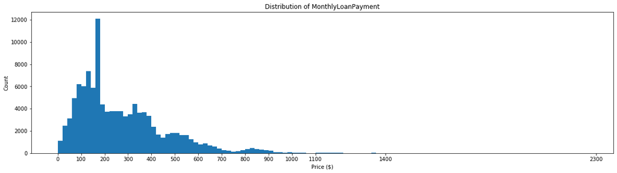

```python
bins =  np.arange(df['MonthlyLoanPayment'].min(), df['MonthlyLoanPayment'].max() + 20, 20);
plt.figure(figsize=[20, 5]);
plt.hist(df['MonthlyLoanPayment'], bins=bins);
plt.xlabel('Price ($)');
plt.xticks([0,100,200,300,400,500,600,700,800,900,1000,1100,1400,2300]);
plt.title('Distribution of MonthlyLoanPayment');
plt.ylabel('Count');
plt.show();
# print('Max: ', df['MonthlyLoanPayment'].max(), ';', 'Min: ',df['MonthlyLoanPayment'].min())
```

## Distribution of LoanOriginalAmount

There is a pattern in the char of `LoanOriginalAmount`. Many loans are the amount of multiples of 5,000 (5000, 10000, 15000, 20000.. etc)

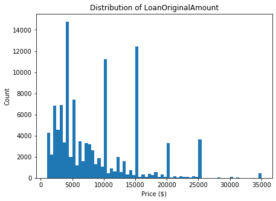

```python
bins =  np.arange(df['LoanOriginalAmount'].min(), df['LoanOriginalAmount'].max() + 500, 500)
plt.figure(figsize=[7, 5])
plt.hist(df['LoanOriginalAmount'], bins=bins);
plt.xlabel('Price ($)')
plt.title('Distribution of LoanOriginalAmount')
plt.ylabel('Count')
plt.show()
```

### Relationship between `BorrowerRate` and other `quantitative variables`

`MonthlyLoanPayment` and `LoanOriginalAmount` show a strong positive correlation among the quantitative variables (not with `BorrowerRate`). However, there are not any positive correlations between `BorrowerRate` and the other quantitative variables, while `LoanOriginalAmount` and `MonthlyLoanPayment` show weak negative correlations (-0.33, -0.25 respectively) with `BorrowerRate`.

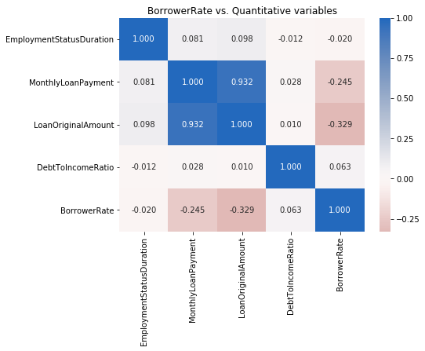

```python
# correlation plot
plt.figure(figsize = [7, 5]);
sns.heatmap(df[quantitative].corr(), annot = True, fmt = '.3f',
           cmap = 'vlag_r', center = 0);
plt.title('BorrowerRate vs. Quantitative variables');
plt.show();
```

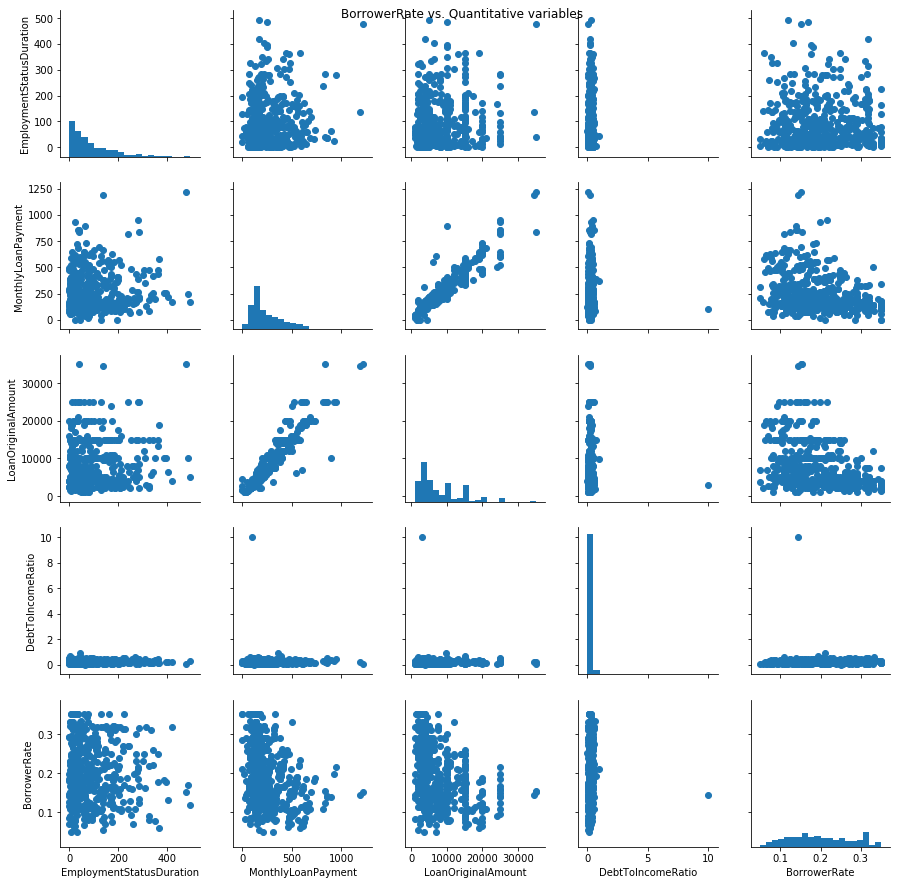

```python
samples = np.random.choice(df.shape[0], 500, replace = False);
df_samp = df.loc[samples,:];

g = sns.PairGrid(data = df_samp, vars = quantitative);
g = g.map_diag(plt.hist, bins = 20);
g.fig.suptitle('BorrowerRate vs. Quantitative variables');
g.map_offdiag(plt.scatter);
```

### Relationship between `BorrowerRate` and other `categorical variables`

#### Relationship `BorrowerRate` vs. `ProsperRating (Alpha)`, `CreditGrade` and `ProsperScore`

As can be seen the bar charts below, it is clear that the better `CreditGrade/ProsperRating (Alpha)/ProsperScore` (three scores related to credit) is, the lower `BorrowerRate` is.

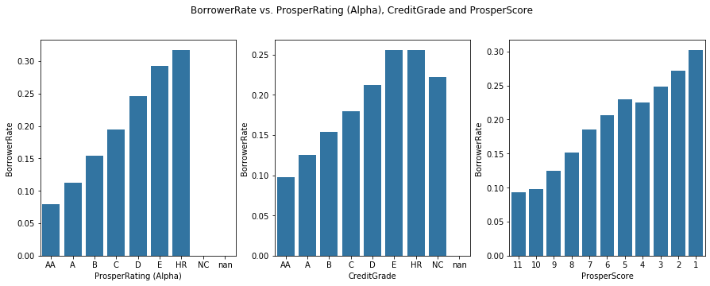

```python
fig, ax = plt.subplots(ncols=3, figsize = [15,5]);

default_color = sns.color_palette()[0];
sns.barplot(x = df.groupby(['ProsperRating (Alpha)'])['BorrowerRate'].mean().sort_values(ascending=False).index,
              y = df.groupby(['ProsperRating (Alpha)'])['BorrowerRate'].mean().sort_values(ascending=False).values,
             color = default_color, ax = ax[0]);
sns.barplot(x = df.groupby(['CreditGrade'])['BorrowerRate'].mean().sort_values(ascending=False).index,
            y = df.groupby(['CreditGrade'])['BorrowerRate'].mean().sort_values(ascending=False).values,
             color = default_color, ax = ax[1]);
sns.barplot(x = df.groupby(['ProsperScore'])['BorrowerRate'].mean().sort_values(ascending=False).index,
            y = df.groupby(['ProsperScore'])['BorrowerRate'].mean().sort_values(ascending=False).values,
             color = default_color, ax = ax[2]);
plt.suptitle("BorrowerRate vs. ProsperRating (Alpha), CreditGrade and ProsperScore", y = 1)
for i in [0,1,2]:
    ax[i].set_ylabel('BorrowerRate');
plt.show();
```

### Relationship between `BorrowerRate` and other `categorical variables`

#### Relationship between `BorrowerRate` by `Term`

In terms of the relationship between `BorrowerRate` and `Term`, it is obvious that shoter term turns out to be lower interest.

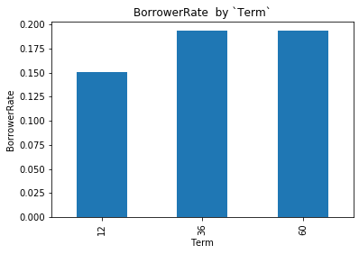

```python
df.groupby('Term')['BorrowerRate'].mean().plot.bar();
plt.title('BorrowerRate  by `Term`');
plt.ylabel('BorrowerRate')
plt.show();
```

### Relationship between `BorrowerRate` and other `categorical variables`

#### Relationship between `BorrowerRate` between `IncomeRange` and `BorrowerRate`

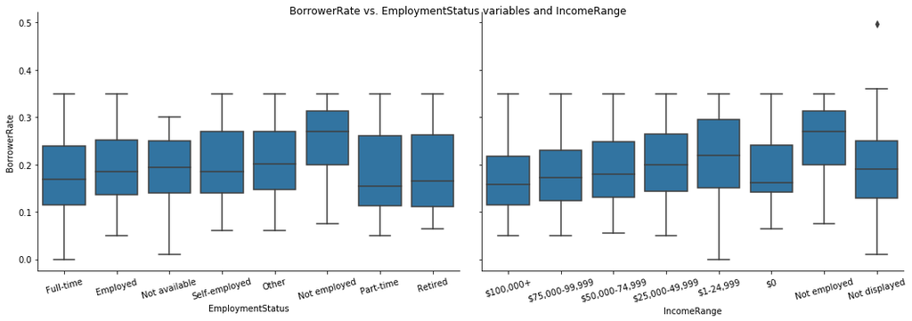

```python
categoric_vars_box = ['EmploymentStatus', 'IncomeRange'];
samples = np.random.choice(df.shape[0], 10000, replace = False);
loan_df_samp = df.loc[samples,:];

def boxgrid(x, y, **kwargs):
    """ Quick hack for creating box plots with seaborn's PairGrid. """

    default_color = sns.color_palette()[0]
    sns.boxplot(x, y, color = default_color);
    plt.xticks(rotation = 15);


plt.figure(figsize = [10, 10]);
g = sns.PairGrid(data = loan_df_samp, y_vars = [ 'BorrowerRate'],
                x_vars = categoric_vars_box, size = 5, aspect = 1.5)
g.fig.suptitle('BorrowerRate vs. EmploymentStatus variables and IncomeRange');
g.map(boxgrid);
plt.xticks(rotation = 15);
plt.show();
```

### Relationship between `BorrowerRate` and other `categorical variables`

#### Relationship between `BorrowerRate` by `IsBorrowerHomeowner` and `IncomeVerifiable`

The borrowers having houses also get lower `BorrowerRate` than the others. Morevoer, if the borrowers verify their income, they get lower interest rate.

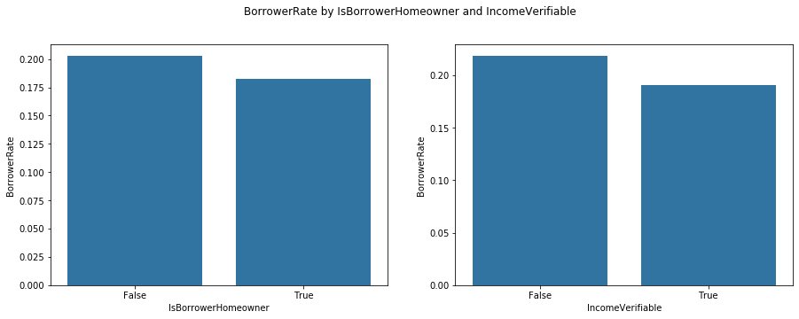

```python
fig, ax = plt.subplots(ncols=2, figsize = [15,5])

default_color = sns.color_palette()[0]
sns.barplot(x = df.groupby(['IsBorrowerHomeowner'])['BorrowerRate'].mean().sort_values(ascending=False).index,
              y = df.groupby(['IsBorrowerHomeowner'])['BorrowerRate'].mean().sort_values(ascending=False).values,
             color = default_color, ax = ax[0])
sns.barplot(x = df.groupby(['IncomeVerifiable'])['BorrowerRate'].mean().sort_values(ascending=False).index,
            y = df.groupby(['IncomeVerifiable'])['BorrowerRate'].mean().sort_values(ascending=False).values,
             color = default_color, ax = ax[1])
plt.suptitle("BorrowerRate by IsBorrowerHomeowner and IncomeVerifiable", y = 1)
for i in [0,1]:
    ax[i].set_ylabel('BorrowerRate');
plt.show()
```

### Relationship between some `categorical variables`

According to the plot, there is no strong relationship between `ProsperScore`/`ProsperRating (Alpha)` and `IncomeRange`.

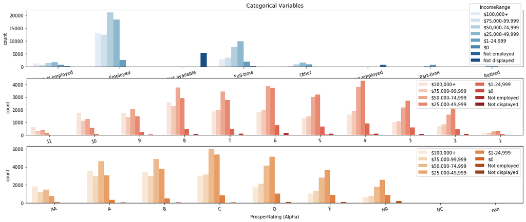

```python
# let's have look at the relationships between categorical variables
plt.figure(figsize = [20, 8]);

# subplot 1: EmploymentStatus vs IncomeRange
plt.subplot(3, 1, 1);
sns.countplot(data = df, x = 'EmploymentStatus', hue = 'IncomeRange', palette = 'Blues');
plt.xticks(rotation = 15);
plt.title('Categorical Variables');

# subplot 2: ProsperScore vs. IncomeRange
ax = plt.subplot(3, 1, 2);
sns.countplot(data = df, x = 'ProsperScore', hue = 'IncomeRange', palette = 'Reds');
ax.legend(ncol = 2) # re-arrange legend to reduce overlapping
plt.xticks(rotation = 15);


# # subplot 3: Term vs. IncomeRange
# ax = plt.subplot(5, 1, 3)
# sns.countplot(data = df, x = 'Term', hue = 'IncomeRange', palette = 'Greens')
# ax.legend(loc = 1, ncol = 2) # re-arrange legend to remove overlapping
# plt.xticks(rotation = 15)

# # subplot 4: ListingCategory vs. IncomeRange
# ax = plt.subplot(5, 1, 4)
# sns.countplot(data = df, x = 'ListingCategory', hue = 'IncomeRange', palette = 'Oranges')
# ax.legend(loc = 1, ncol = 2) # re-arrange legend to remove overlapping
# plt.xticks(rotation = 15)

# subplot 5: ProsperRating (Alpha) vs. IncomeRange
ax = plt.subplot(3, 1, 3);
sns.countplot(data = df, x = 'ProsperRating (Alpha)', hue = 'IncomeRange', palette = 'Oranges');
ax.legend(loc = 1, ncol = 2); # re-arrange legend to remove overlapping
plt.xticks(rotation = 15);

plt.show();
```

### What is the relationship between BorrowerRate and IncomeRange by ProsperRating (Alpha), ProsperScore, CreditGrade?

The graphs show the `IncomeRange` vs. `BorrowerRating` by `ProsperRating (Alpha)`, `ProsperScore`, `CreditGrade`. It seems that there is neither high positive nor negative correlations between borrowers' incomes and the interest rate. Instead, `BorrowerRating` shows a rather constant relationship with borrowers' `ProsperRating (Alpha)`, `ProsperScore`, `CreditGrade`. Even if a person has a low income, if the person has a high credit score or rating, the interest rate is the same as a persion with a high income and high grade.

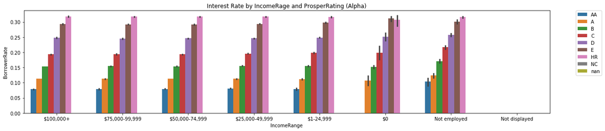

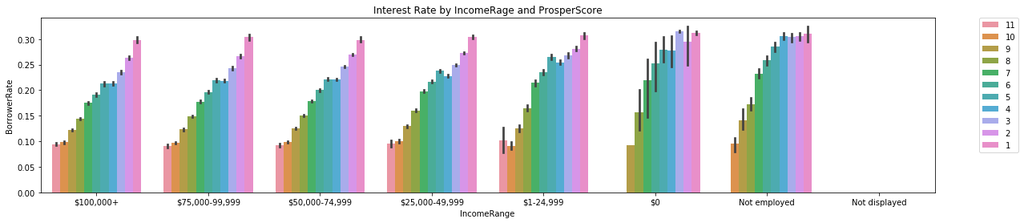

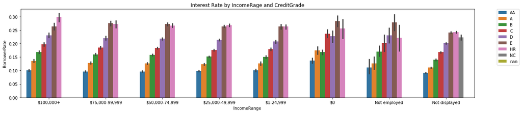

```python
for i in ['ProsperRating (Alpha)', 'ProsperScore', 'CreditGrade']:
    plt.figure(figsize = [20, 4]);
    sns.barplot(x = df['IncomeRange'], y = df['BorrowerRate'], hue = df[i]);
    plt.legend(framealpha = 1, title = i);
    plt.legend(bbox_to_anchor=(1.05, 1), loc=2, borderaxespad=0.);
    plt.title('Interest Rate by IncomeRage and {}'.format(i));
```

We can see the interest rate decreases as the `ProsperRating (Alpha)` increases (gets better) as seen in **### What is the relationship between BorrowerRate and IncomeRange by ProsperRating (Alpha), ProsperScore, CreditGrade?** plot. However, no conspicuous differences are seen from the above plot between homeowners and no homeowners.

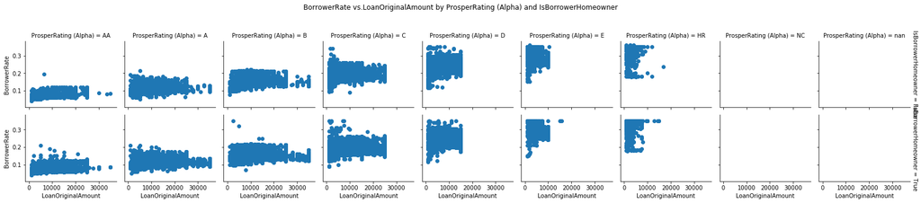

```python
g = sns.FacetGrid(data = df, col = 'ProsperRating (Alpha)', row = 'IsBorrowerHomeowner',
                  size = 2.5, margin_titles = True);
g.map(plt.scatter, 'LoanOriginalAmount', 'BorrowerRate');
plt.subplots_adjust(top=0.8);
g.fig.suptitle('BorrowerRate vs.LoanOriginalAmount by ProsperRating (Alpha) and IsBorrowerHomeowner');
```

Here comes the same pattern as in the above plots. The better the credit rating/grades, the lower the interest rate, but there is no meaningful difference in `BorrowerRate` depending on `IncomeVerifiable`.

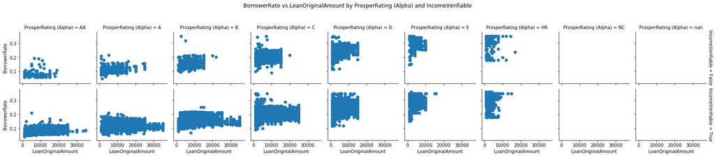

```python
g = sns.FacetGrid(data = df, col = 'ProsperRating (Alpha)', row = 'IncomeVerifiable',
                  size = 2.5, margin_titles = True)
g.map(plt.scatter, 'LoanOriginalAmount', 'BorrowerRate');
plt.subplots_adjust(top=0.8);
g.fig.suptitle('BorrowerRate vs.LoanOriginalAmount by ProsperRating (Alpha) and IncomeVerifiable');
```

### What if put both IncomeVerifiable and IsBorrowerHomeowner together?

This time I compare `BorrowerRate` vs. `LoanOriginalAmount` by both `IncomeVerifiable` and`IsBorrowerHomeowner` from sampling 3000 loans. Nevertherless, it is hard to see any conspicuous relationships between `BorrowerRate` and `IncomeVerifiable`, `IsBorrowerHomeowner`.

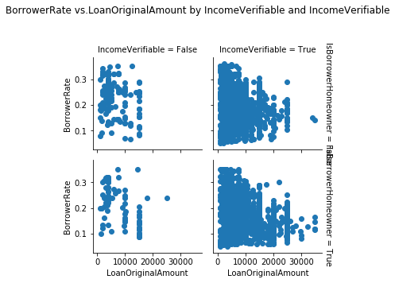

```python
samples = np.random.choice(df.shape[0], 3000, replace = False)
df_samp = df.loc[samples,:]

g = sns.FacetGrid(data = df_samp, col = 'IncomeVerifiable', row = 'IsBorrowerHomeowner',
                  size = 2.5, margin_titles = True)
g.map(plt.scatter, 'LoanOriginalAmount', 'BorrowerRate');
plt.subplots_adjust(top=0.8);
g.fig.suptitle('BorrowerRate vs.LoanOriginalAmount by IncomeVerifiable and IncomeVerifiable');
```

### Deep look into the relationship between BorrowerRate vs. rosperRating (Alpha) by IsBorrowerHomeowner and IncomeVerifiable

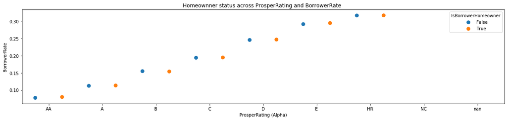

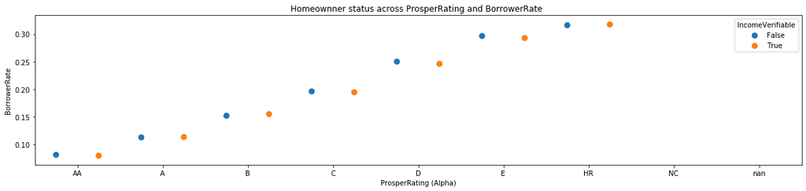

```python
for i in ['IsBorrowerHomeowner', 'IncomeVerifiable']:
    plt.figure(figsize = [20, 4])
    sns.pointplot(x = df['ProsperRating (Alpha)'], y = df['BorrowerRate'], hue = df[i],
                  dodge = 0.5, linestyles = "");
    plt.title('Homeownner status across ProsperRating and BorrowerRate ');
```

## Conclusion

In conclusion, according to our analysis conducted so far, it is clear that interest rate (`BorrowerRate`) is highly dependant on `CreditGrade`, `ProsperRating (Alpha)`, and `ProsperScore`. Other variables like `IncomeRange`,`IncomeVerifiable` or `IsBorrowerHomeowner` also play a role in determining interest rate but it is minor comapred to `CreditGrade`, `ProsperRating (Alpha)`, and `ProsperScore`. Especially, I expected that `IncomeRange` would play a major role for `BorrowerRate` at the beginnning of this research, but in fact, it is not a essential factor for determining interest rate according to our research. Instead, regardless of a borrower's income, if the person has a good credit rating or score (`CreditGrade`, `ProsperRating (Alpha)`, or `ProsperScore`) then the person can get a low interest rate.